# The bestiary of functions

PCB 6455 / BSC 4933: Biometry | Lecture 10

Dr. Brian Maitner

## Today’s agenda

- Reading a function by its shape
- The right curve depends on the question
- Modifying a function to fit
- Piecewise functions and derivatives in R (3.6)

Type and run on a code block: type it into your script and run it. You will need it later.

Code without the label is there to watch.

## Where we left off

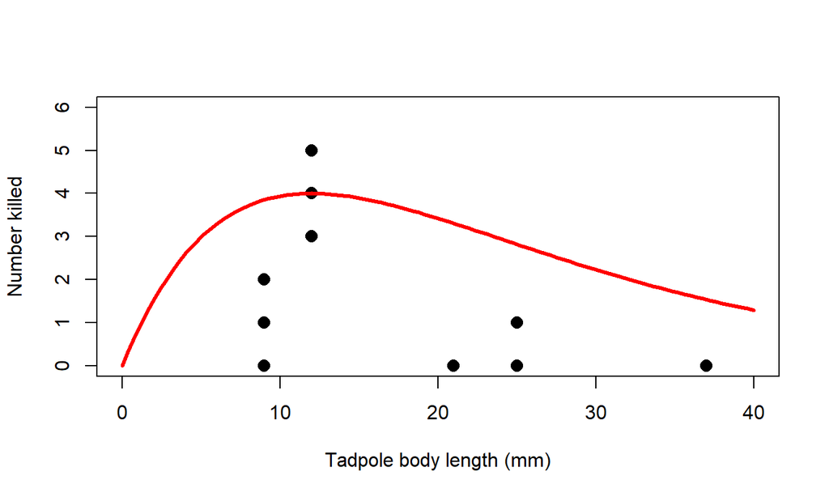

The Ricker had the right kind of shape, but its right tail is too heavy. Score: **87.5**.

## Two ways forward

1. **Try a different function**, one whose shape matches better.
2. **Modify the function you have**, so its shape changes.

Either way you need a vocabulary of shapes. That is what the **bestiary** is.

## Get set up

Run this so the rest of today works.

```r
library(emdbook)
data(ReedfrogSizepred)
data(ReedfrogFuncresp)
tadpoles <- ReedfrogSizepred
kills_by_density <- ReedfrogFuncresp

ricker <- function(x, a = 1, b = 1){
  a * x * exp(-b * x)
}

michaelis_menten <- function(x, a = 1, b = 1){
  a * x / (b + x)
}
```

## Reading a function by its shape

## Read a function by its ends and its middle

Three questions to ask of any function:

1. What happens at the **left end**?
2. What happens at the **right end**?
3. What happens **in between**? Does it rise, fall, peak, level off, or switch?

Bolker’s Table 3.1 sorts the whole bestiary by exactly these.

## A catalog of shapes

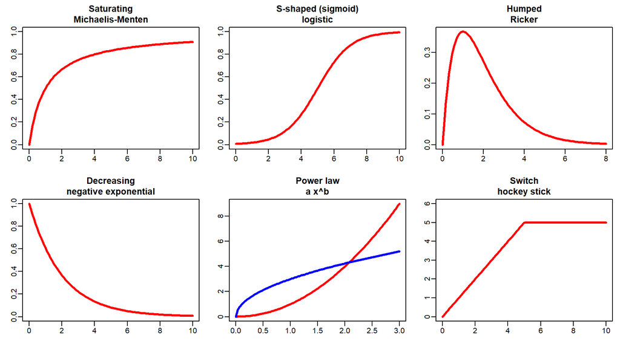

## Your turn: which shape would you try first?

No code. For each, name a starting shape and one reason.

1. Seeds eaten by a mouse ~ seed density
2. Light level ~ depth in a lake
3. Bird body mass ~ leg length
4. Probability a tree has flowered ~ trunk diameter
5. Total offspring produced ~ population density
6. Food eaten by a filter feeder with a hard maximum ~ food concentration

Read `~` as “depends on”: **response ~ predictor**, the y axis on the left and the x axis on the right.

More than one answer can be defensible. The reason is the point.

## The right curve depends on the question

## A second tadpole experiment

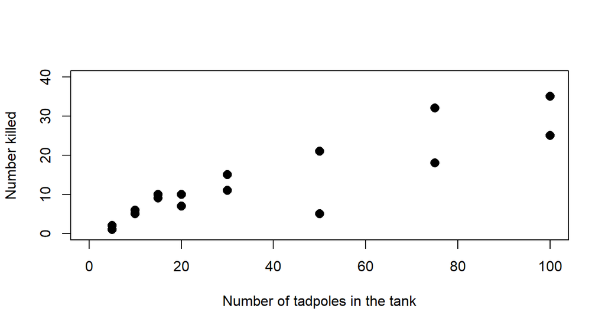

Same predators, same prey. This time the question is **how many** tadpoles, not **how big**. What shape is this?

## Michaelis-Menten fits this one

```r
plot(kills_by_density$Initial, kills_by_density$Killed,
     xlim = c(0, 100), ylim = c(0, 40),
     xlab = "Number of tadpoles in the tank", ylab = "Number killed")
curve(michaelis_menten(x, a = 60, b = 100), add = TRUE, col = "red", lwd = 2)
```

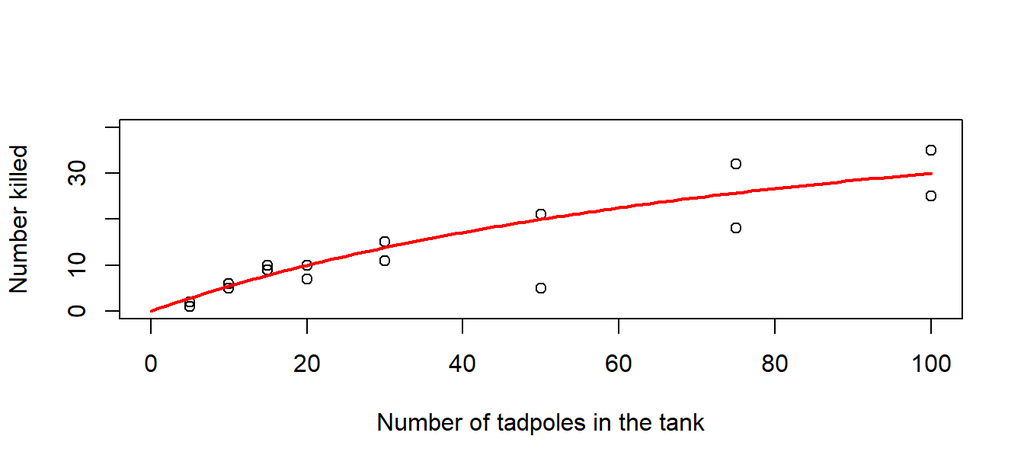

The curve that failed on **size** in Lecture 9 fits **density**.

## Your turn: how high does it go?

```r
a_try <- 60                    # the asymptote
b_try <- 100                   # the half-saturation point

plot(kills_by_density$Initial, kills_by_density$Killed,
     xlim = c(0, 100), ylim = c(0, 40))
curve(michaelis_menten(x, a = a_try, b = b_try), add = TRUE, col = "red", lwd = 2)

sum((kills_by_density$Killed -
     michaelis_menten(kills_by_density$Initial, a_try, b_try))^2)
```

Starting score: **404**. Now try `a_try <- 150` and `b_try <- 390`.

What does that tell you about the maximum number of kills?

## Modifying a function to fit

## Four ways to change a function

Start from any $f(x)$:

| Change | Math | Effect |
| --- | --- | --- |
| **Scale** | $a \cdot f(x)$ | taller or shorter |
| **Stretch** | $f(x / b)$ | wider or narrower |
| **Shift** | $f(x - c)$ | slides right |
| **Bend** | $f(x)^{\alpha}$ | changes the shape itself |

## What each one does

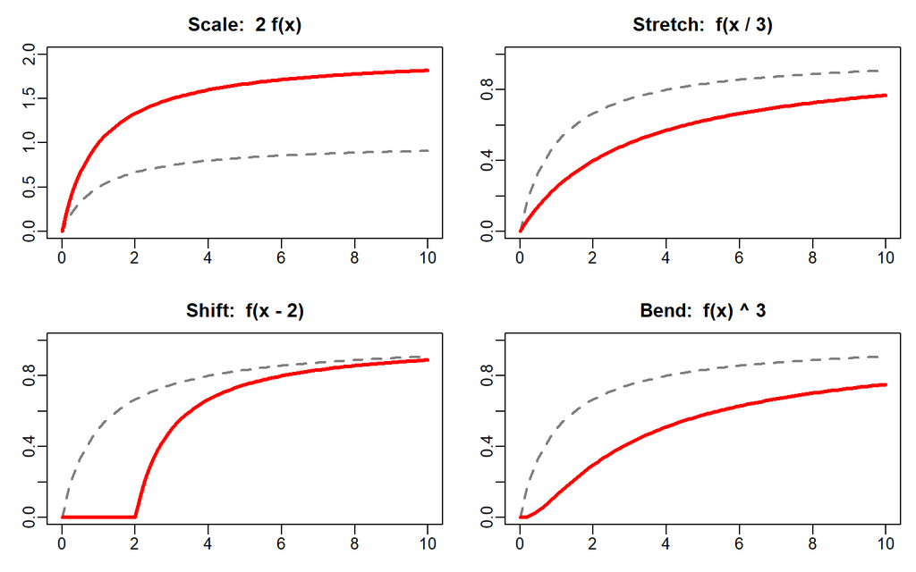

Gray dashed: $f(x) = x / (1 + x)$. Red: the changed version.

## Power laws

$$f(x) = a\,x^{b}$$

- $a$: scale, the value at $x = 1$
- $b$: the exponent. $b > 1$ accelerates, $0 < b < 1$ decelerates, $b < 0$ decreases

```r
power_law <- function(x, a = 1, b = 1){
  a * x^b
}
```

On log-log axes, a power law is a **straight line** with slope $b$.

## A power law in AVONET

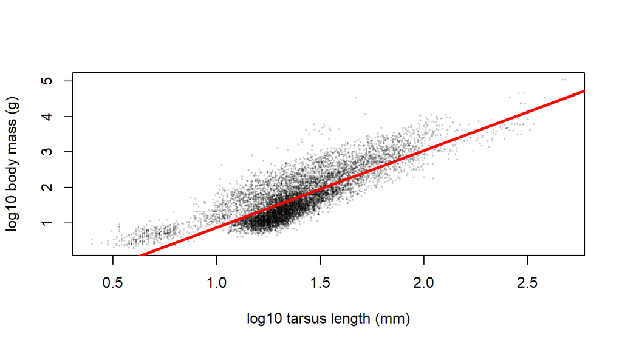

Slope about **2.2**: body mass rises roughly as leg length to the power 2.2.

## Fixing the tadpoles

## The Ricker’s hump is too wide

A power **bends** a curve’s shape.

Raise the Ricker to a power greater than 1 and the hump gets **narrower**, with lighter tails.

That is exactly what the tadpole data need.

## The only change is an exponent

**Ricker**, as you wrote it last time

$$f(x) = a\,x\,e^{-b x}$$

the same curve, written with the peak’s height $h$ and position $p$

$$f(x) = h \left( \frac{x}{p}\, e^{\,1 - x/p} \right)$$

**Power-Ricker**

$$f(x) = h \left( \frac{x}{p}\, e^{\,1 - x/p} \right)^{\alpha}$$

Everything in the brackets is the Ricker.

The only new thing is the $\alpha$.

## Side by side

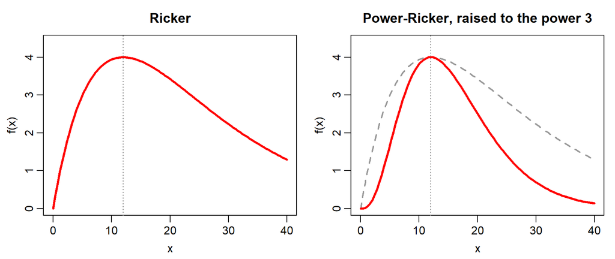

Same peak, same height. The power **narrows the hump** and **pulls the right tail down**.

## The power-Ricker, in math and in R

**Math**

$$f(x) = h \left( \frac{x}{p}\, e^{\,1 - x/p} \right)^{\alpha}$$

- $h$: the height of the peak
- $p$: where the peak is
- $\alpha$: how narrow the hump is ($\alpha > 0$)

With $\alpha = 1$ it **is** the Ricker.

**R**

```r
power_ricker <- function(x, height, peak, alpha){
  height * (x / peak * exp(1 - x / peak))^alpha
}
```

- the Ricker part is inside the brackets
- `^alpha` is the bend

## Your turn: fix the fit

```r
power_ricker <- function(x, height, peak, alpha){
  height * (x / peak * exp(1 - x / peak))^alpha
}

alpha_try <- 1                 # change this

plot(tadpoles$TBL, tadpoles$Kill, xlim = c(0, 40), ylim = c(0, 6))
curve(power_ricker(x, height = 4, peak = 12, alpha = alpha_try),
      add = TRUE, col = "red", lwd = 2)

sum((tadpoles$Kill - power_ricker(tadpoles$TBL, 4, 12, alpha_try))^2)
```

With `alpha_try <- 1` you should get **87.5**, last lecture’s score. The best any Ricker can do is **24.9**. Can you beat it?

## What $\alpha$ does

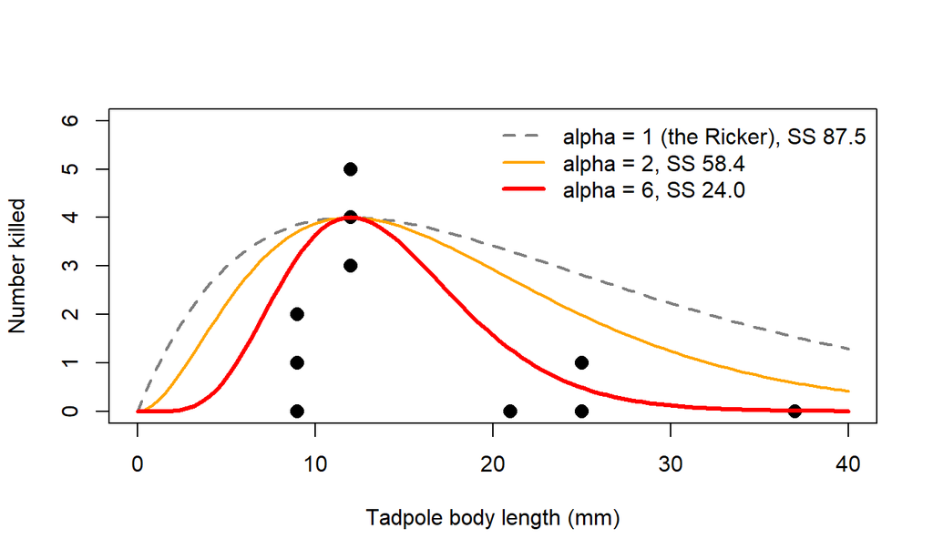

Same peak, same height. Bigger $\alpha$, narrower hump.

## How far should you go?

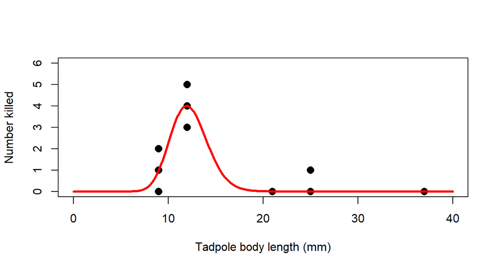

The best fit has $\alpha = 38$ and a score of **5**. **Do you believe it?**

## Piecewise functions and derivatives in R

## Piecewise functions with `ifelse()`

**Math**: a hockey stick

$$f(x) = \begin{cases} a\,x & \text{if } x < s \\ a\,s & \text{if } x \ge s \end{cases}$$

- $a$: the slope before the switch
- $s$: where it switches

**R**

```r
hockey_stick <- function(x, a, s){
  ifelse(x < s, a * x, a * s)
}
```

`ifelse(condition, if true, if false)`

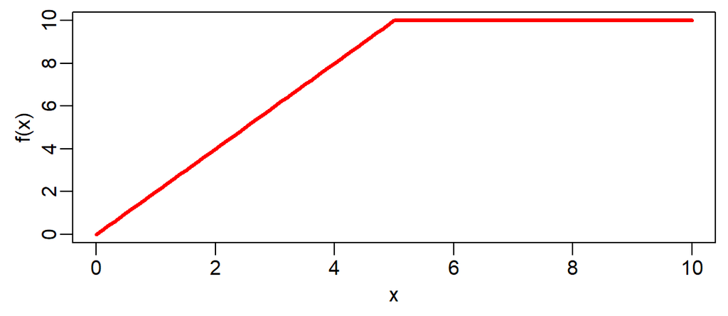

## Your turn: a threshold

A threshold is flat, jumps at $s$, then is flat again: $f(x) = a_1$ if $x < s$, otherwise $a_2$.

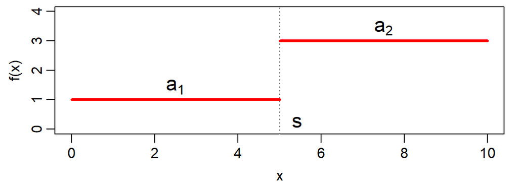

```r
threshold <- function(x, a1, a2, s){

}

curve(threshold(x, a1 = 1, a2 = 3, s = 5), from = 0, to = 10)
```

## R can do the calculus

Last lecture the book told us the Ricker peaks at $x = 1/b$. Check it with `D()`:

```r
d_ricker <- D(expression(a * x * exp(-b * x)), "x")
d_ricker
```

```
a * exp(-b * x) - a * x * (exp(-b * x) * b)
```

```r
eval(d_ricker, list(a = 1, b = 0.25, x = 1 / 0.25))
```

```
[1] 0
```

```r
eval(d_ricker, list(a = 2, b = 0.25, x = 0))
```

```
[1] 2
```

Slope **0** at $x = 1/b$: that is the peak. Slope **$a$** at $x = 0$: the initial slope.

## Remainder of class

Complete **3.6**, the R supplement:

- 3.6.1 Plotting functions (most of today)
- 3.6.2 Piecewise functions with `ifelse()`
- 3.6.3 Derivatives with `D()` and `deriv()`

Code: `R_scripts/Chapter_3_examples.R`

## Before next class

Read Bolker **4.1 to 4.2**, and **4.4**

Next time: probability and stochastic distributions